# survival lecture 8

Steve Simon

May 27, 2018

Lecture 8. Competing risk models.

This file does not need any special libraries other than the ones listed below. Many of the data sets in this program use data from Hosmer, Lemeshow, and May. I made one minor change, however, which was to force all the variable names to lower case.

```r
library(broom)
library(dplyr)
```

```r
library(ggplot2)
library(magrittr)
library(survival)
library(tidyr)
```

Read in the leader data set.

```r
fn <- "../../data/leader.RData"
load(fn)
leader <- leader[is.finite(leader$age), ]
```

Calculate some simple descriptive statistics.

```r
summary(leader$years)
```

```
##    Min. 1st Qu.  Median    Mean 3rd Qu.    Max.
##   0.000   1.000   3.000   5.114   7.000  27.000
```

```r
table(leader$lost)
```

```
##
##         still in power    constitutional exit          natural death
##                    111                    146                     27
## nonconstitutional exit
##                    154
```

```r
table(leader$manner)
```

```
##
##    constitutional ascent nonconstitutional ascent
##                      280                      158
```

```r
summary(leader$start)
```

```
##    Min. 1st Qu.  Median    Mean 3rd Qu.    Max.
##    1960    1965    1973    1973    1979    1987
```

```r
table(leader$military)
```

```
##
##  no yes
## 294 144
```

```r
summary(leader$age)
```

```
##    Min. 1st Qu.  Median    Mean 3rd Qu.    Max.
##   17.00   41.00   50.00   49.39   56.75   81.00
```

```r
table(leader$conflict)
```

```
##
##         low conflict medium/high conflict
##                  166                  272
```

```r
summary(leader$loginc)
```

```
##    Min. 1st Qu.  Median    Mean 3rd Qu.    Max.
##   4.094   5.075   5.858   5.916   6.565   9.546
```

```r
summary(leader$growth)
```

```
##    Min. 1st Qu.  Median    Mean 3rd Qu.    Max.
##   -7.00    0.50    1.50    1.63    3.40    8.50
```

```r
summary(leader$pop)
```

```
##     Min.  1st Qu.   Median     Mean  3rd Qu.     Max.
##    0.008    2.600    7.000   35.780   24.000 1088.000
```

```r
summary(leader$land)
```

```
##    Min. 1st Qu.  Median    Mean 3rd Qu.    Max.
##    0.02   49.00  238.00  739.97  912.00 9596.00
```

```r
summary(leader$literacy)
```

```
##    Min. 1st Qu.  Median    Mean 3rd Qu.    Max.
##    5.00   32.00   65.00   59.41   85.00   99.00
```

```r
table(leader$region)
```

```
##
##   middle east        africa          asia latin america
##            60           132            91           155
```

First, let’s look at this model in a binary fashion, with lost = “still in power” as censored observations and “constitutional exit” and “natural death” and “non-constitutional exit” as events.

```r
leader$event <-
  (leader$lost=="constitutional exit") +
  (leader$lost=="natural death") +
  (leader$lost=="nonconstitutional exit")

table(leader$lost, leader$event, useNA="ifany")
```

```
##
##                            0   1
##   still in power         111   0
##   constitutional exit      0 146
##   natural death            0  27
##   nonconstitutional exit   0 154
```

Always check your counts to make sure you have enough events in each group.

```r
table(leader$manner, leader$event)
```

```
##
##                              0   1
##   constitutional ascent     70 210
##   nonconstitutional ascent  41 117
```

```r
table(leader$military, leader$event)
```

```
##
##         0   1
##   no   70 224
##   yes  41 103
```

```r
table(leader$conflict, leader$event)
```

```
##
##                          0   1
##   low conflict          42 124
##   medium/high conflict  69 203
```

```r
table(leader$region, leader$event)
```

```
##
##                   0   1
##   middle east    18  42
##   africa         42  90
##   asia           26  65
##   latin america  25 130
```

Create cut-points for continuous outcomes.

```r
leader$start_c <-
  cut(
    leader$start,
    c(1959, 1969, 1979, 1987),
    c("60s", "70s","80s"  )
)
table(leader$start_c)
```

```
##
## 60s 70s 80s
## 176 159 103
```

```r
leader$age_c <-
  cut(
    leader$age,
    c(0, 39, 59, 89),
    c("0-39", "40-59", "60+")
)
table(leader$age_c)
```

```
##
##  0-39 40-59   60+
##    89   265    84
```

```r
leader$loginc_c <-
  cut(
    leader$loginc,
    c(log(c(1, 200, 500, 100000))),
    c("$0-200", "$200-500", "$500+")
)
table(leader$loginc_c)
```

```
##
##   $0-200 $200-500    $500+
##      130      149      159
```

```r
leader$growth_c <-
  cut(
    leader$growth,
    c(-10, 0, 3.9, 10),
    c("neg", "0-3.9%", "4%+")
)
table(leader$growth_c)
```

```
##
##    neg 0-3.9%    4%+
##     85    275     78
```

```r
leader$pop_c <-
  cut(
    leader$pop,
    c(0, 1, 10, 10000),
    c("under 1m", "1-10m", "10m+")
)
table(leader$pop_c)
```

```
##
## under 1m    1-10m     10m+
##       70      189      179
```

```r
leader$land_c <-
  cut(
    leader$land,
    c(0, 100, 1000, 10000),
    c(
      "under 100 sq km",
      "100-1,000 sq km",
      "1,000-10,000 sq km")
)
table(leader$land_c)
```

```
##
##    under 100 sq km    100-1,000 sq km 1,000-10,000 sq km
##                142                198                 98
```

```r
leader$literacy_c <-
  cut(
    leader$literacy,
    c(0, 50, 75, 100),
    c("0-50%", "50-75%", "75-100%")
)
table(leader$literacy_c)
```

```
##
##   0-50%  50-75% 75-100%
##     163     103     172
```

Take a look at the calculations involved.

```r
leader_tally <- table(leader$years, leader$lost)
leader_tally
```

```
##
##      still in power constitutional exit natural death
##   0               7                  34             2
##   1              10                  15             1
##   2               9                  15             2
##   3               8                  17             4
##   4               5                  24             2
##   5               8                  17             1
##   6               7                   8             2
##   7               7                   0             2
##   8               8                   4             0
##   9               6                   0             1
##   10              5                   2             0
##   11              0                   2             1
##   12              5                   1             3
```

[output cut: 43 more lines]

```r
fn <- "../../data/leader_tally.csv"
write.csv(leader_tally, file=fn, row.names=FALSE)
```

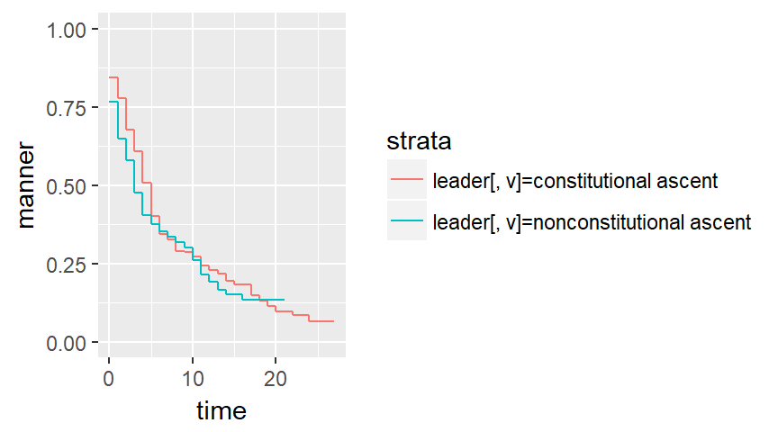

```r
binary_surv <- Surv(leader$years, leader$event)

draw_km <- function(v) {
  survfit(binary_surv~leader[ , v], data=leader)   %>%
    tidy                                           %>%
    ggplot(aes(time, estimate, color=strata))  +
      ylab(v)                                       +
      expand_limits(y=0:1)                          +
      geom_step()                                  %>%
  return
}

draw_km("manner")
```

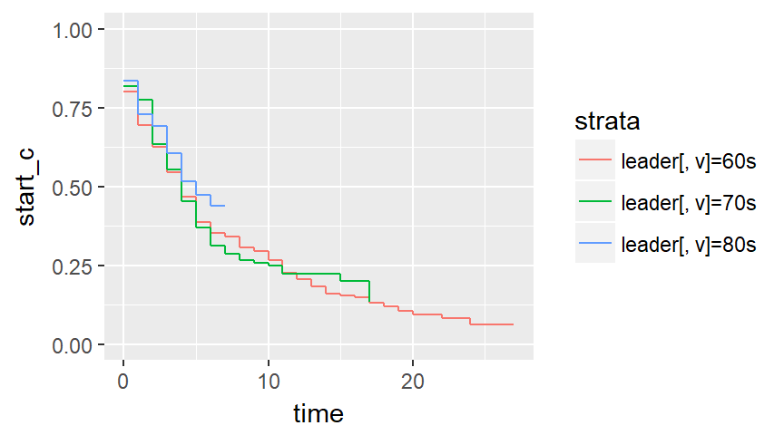

```r
draw_km("start_c")
```

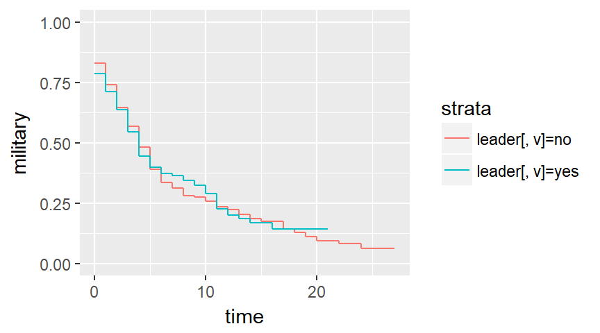

```r
draw_km("military")
```

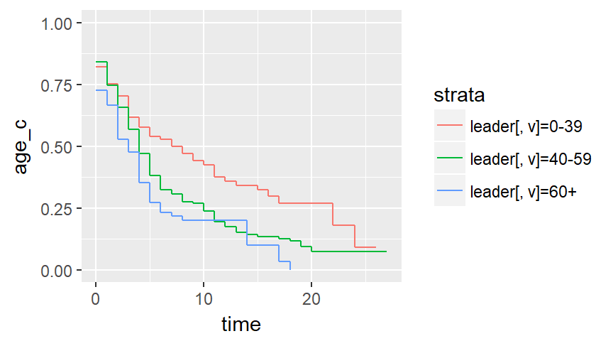

```r
draw_km("age_c")
```

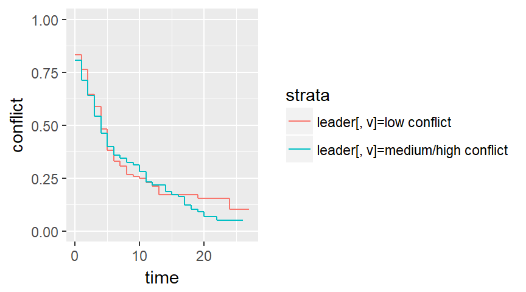

```r
draw_km("conflict")
```

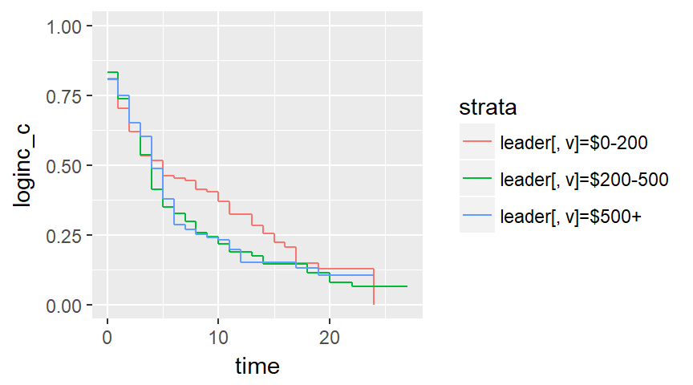

```r
draw_km("loginc_c")
```

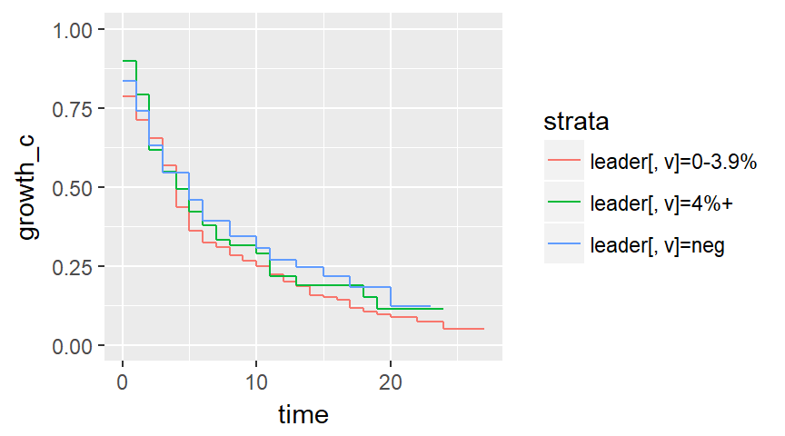

```r
draw_km("growth_c")
```

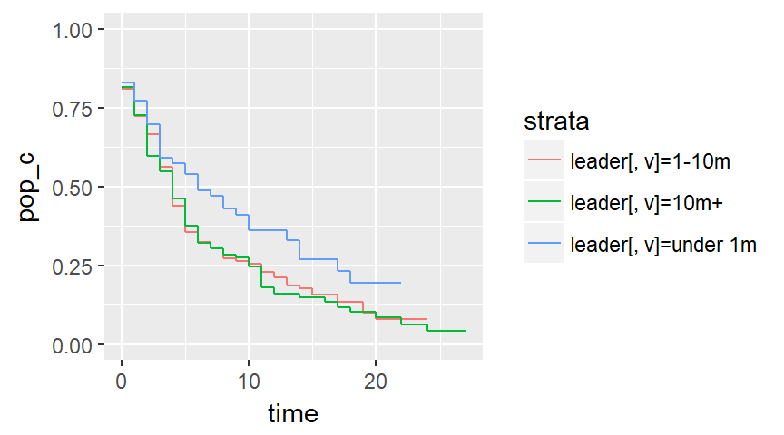

```r
draw_km("pop_c")
```

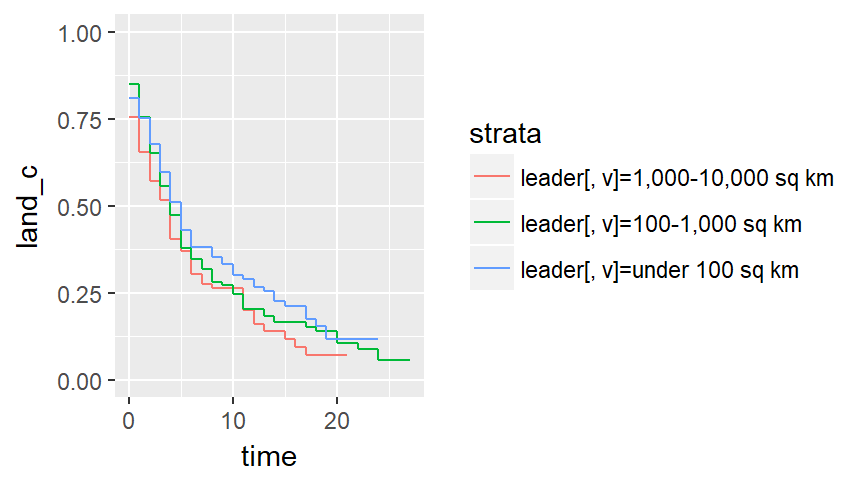

```r
draw_km("land_c")
```

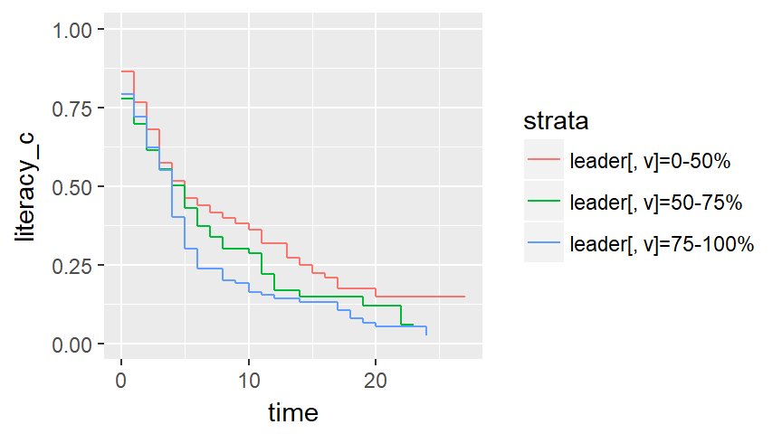

```r
draw_km("literacy_c")
```

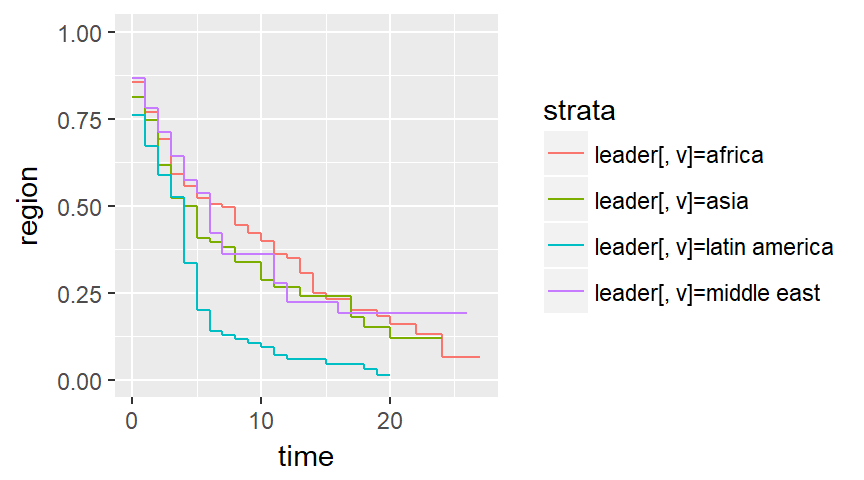

```r
draw_km("region")
```

Fit univariate Cox models

```r
coxph(binary_surv~manner, data=leader)
```

```
## Call:
## coxph(formula = binary_surv ~ manner, data = leader)
##
##                                 coef exp(coef) se(coef)    z    p
## mannernonconstitutional ascent 0.138     1.148    0.116 1.19 0.23
##
## Likelihood ratio test=1.4  on 1 df, p=0.238
## n= 438, number of events= 327
```

```r
coxph(binary_surv~start, data=leader)
```

```
## Call:
## coxph(formula = binary_surv ~ start, data = leader)
##
##           coef exp(coef) se(coef)     z    p
## start -0.00848   0.99156  0.00781 -1.09 0.28
##
## Likelihood ratio test=1.18  on 1 df, p=0.277
## n= 438, number of events= 327
```

```r
coxph(binary_surv~military, data=leader)
```

```
## Call:
## coxph(formula = binary_surv ~ military, data = leader)
##
##                 coef exp(coef) se(coef)     z    p
## militaryyes -0.00827   0.99176  0.11949 -0.07 0.94
##
## Likelihood ratio test=0  on 1 df, p=0.945
## n= 438, number of events= 327
```

```r
coxph(binary_surv~age, data=leader)
```

```
## Call:
## coxph(formula = binary_surv ~ age, data = leader)
##
##        coef exp(coef) se(coef)    z       p
## age 0.02170   1.02194  0.00482 4.51 6.6e-06
##
## Likelihood ratio test=20.1  on 1 df, p=7.31e-06
## n= 438, number of events= 327
```

```r
coxph(binary_surv~conflict, data=leader)
```

```
## Call:
## coxph(formula = binary_surv ~ conflict, data = leader)
##
##                                coef exp(coef) se(coef)    z    p
## conflictmedium/high conflict 0.0547    1.0562   0.1142 0.48 0.63
##
## Likelihood ratio test=0.23  on 1 df, p=0.631
## n= 438, number of events= 327
```

```r
coxph(binary_surv~loginc, data=leader)
```

```
## Call:
## coxph(formula = binary_surv ~ loginc, data = leader)
##
##           coef exp(coef) se(coef)     z    p
## loginc -0.0129    0.9872   0.0480 -0.27 0.79
##
## Likelihood ratio test=0.07  on 1 df, p=0.789
## n= 438, number of events= 327
```

```r
coxph(binary_surv~growth, data=leader)
```

```
## Call:
## coxph(formula = binary_surv ~ growth, data = leader)
##
##            coef exp(coef) se(coef)     z    p
## growth -0.00155   0.99845  0.01860 -0.08 0.93
##
## Likelihood ratio test=0.01  on 1 df, p=0.934
## n= 438, number of events= 327
```

```r
coxph(binary_surv~pop, data=leader)
```

```
## Call:
## coxph(formula = binary_surv ~ pop, data = leader)
##
##         coef exp(coef) se(coef)    z    p
## pop 0.000387  1.000387 0.000442 0.88 0.38
##
## Likelihood ratio test=0.69  on 1 df, p=0.406
## n= 438, number of events= 327
```

```r
coxph(binary_surv~land, data=leader)
```

```
## Call:
## coxph(formula = binary_surv ~ land, data = leader)
##
##          coef exp(coef) se(coef)    z     p
## land 5.95e-05  1.00e+00 3.59e-05 1.66 0.097
##
## Likelihood ratio test=2.44  on 1 df, p=0.118
## n= 438, number of events= 327
```

```r
coxph(binary_surv~literacy, data=leader)
```

```
## Call:
## coxph(formula = binary_surv ~ literacy, data = leader)
##
##             coef exp(coef) se(coef)    z      p
## literacy 0.00622   1.00624  0.00200 3.11 0.0019
##
## Likelihood ratio test=9.88  on 1 df, p=0.00167
## n= 438, number of events= 327
```

```r
coxph(binary_surv~region, data=leader)
```

```
## Call:
## coxph(formula = binary_surv ~ region, data = leader)
##
##                        coef exp(coef) se(coef)     z       p
## regionafrica        -0.0587    0.9430   0.1873 -0.31 0.75394
## regionasia           0.1425    1.1531   0.1982  0.72 0.47231
## regionlatin america  0.6592    1.9331   0.1795  3.67 0.00024
##
## Likelihood ratio test=30.3  on 3 df, p=1.21e-06
## n= 438, number of events= 327
```

Fit a multivariate model

```r
binary_mv <-
  coxph(
    binary_surv~
      manner +
      military +
      age,
    data=leader
  )
summary(binary_mv)
```

```
## Call:
## coxph(formula = binary_surv ~ manner + military + age, data = leader)
##
##   n= 438, number of events= 327
##
##                                     coef exp(coef)  se(coef)      z
## mannernonconstitutional ascent  0.359963  1.433277  0.153237  2.349
## militaryyes                    -0.128457  0.879451  0.157289 -0.817
## age                             0.024148  1.024442  0.004967  4.862
##                                Pr(>|z|)
## mannernonconstitutional ascent   0.0188 *
## militaryyes                      0.4141
## age                            1.16e-06 ***
## ---
## Signif. codes:  0 '***' 0.001 '**' 0.01 '*' 0.05 '.' 0.1 ' ' 1
##
##                                exp(coef) exp(-coef) lower .95 upper .95
## mannernonconstitutional ascent    1.4333     0.6977    1.0614     1.935
## militaryyes                       0.8795     1.1371    0.6461     1.197
## age                               1.0244     0.9761    1.0145     1.034
##
## Concordance= 0.59  (se = 0.021 )
## Rsquare= 0.058   (max possible= 1 )
## Likelihood ratio test= 26.14  on 3 df,   p=8.907e-06
## Wald test            = 26.66  on 3 df,   p=6.937e-06
## Score (logrank) test = 26.44  on 3 df,   p=7.711e-06
```

Compare the Martingale residuals to each independent variable already in the model to look for non-linearities.

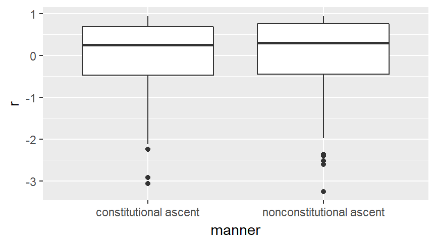

```r
leader$r <- residuals(binary_mv)
ggplot(leader, aes(manner, r))   +
  geom_boxplot()
```

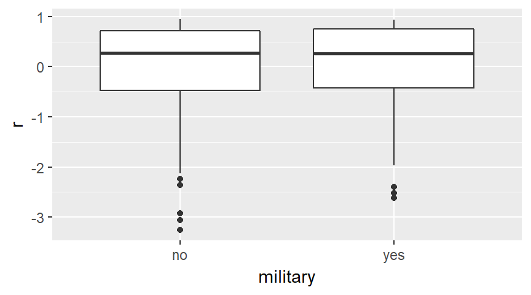

```r
ggplot(leader, aes(military, r)) +
  geom_boxplot()                 +
  geom_smooth(se=TRUE)
```

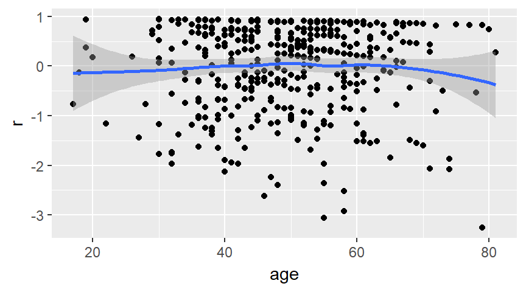

```r
ggplot(leader, aes(age, r))      +
  geom_point()                   +
  geom_smooth(se=TRUE)
```

Compare the Martingale residuals to variables not yet in the model.

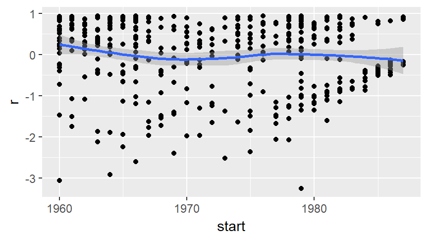

```r
leader$r <- residuals(binary_mv)
ggplot(leader, aes(start, r))    +
  geom_point()                   +
  geom_smooth(se=TRUE)
```

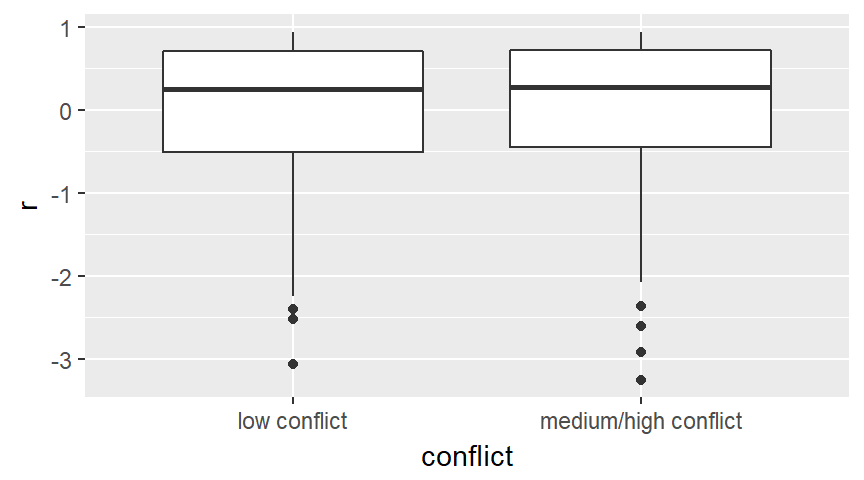

```r
ggplot(leader, aes(conflict, r)) +
  geom_boxplot()
```

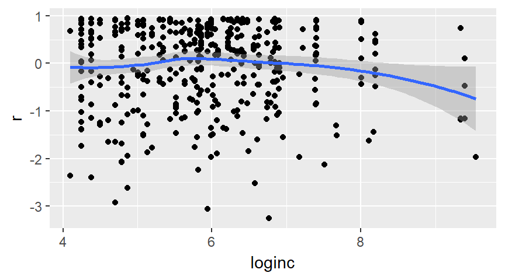

```r
ggplot(leader, aes(loginc, r))   +
  geom_point()                   +
  geom_smooth(se=TRUE)
```

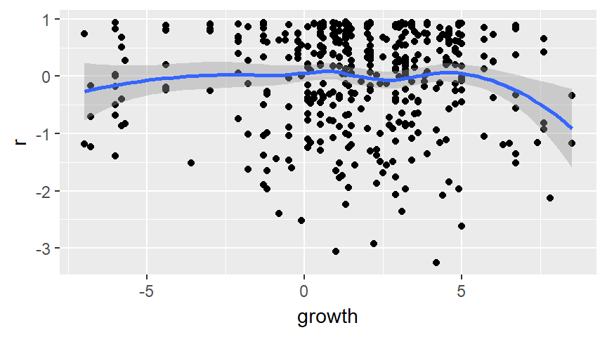

```r
ggplot(leader, aes(growth, r))   +
  geom_point()                   +
  geom_smooth(se=TRUE)
```

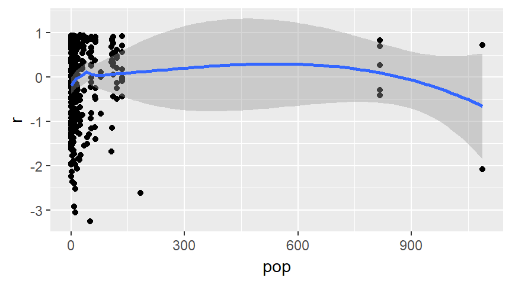

```r
ggplot(leader, aes(pop, r))      +
  geom_point()                   +
  geom_smooth(se=TRUE)
```

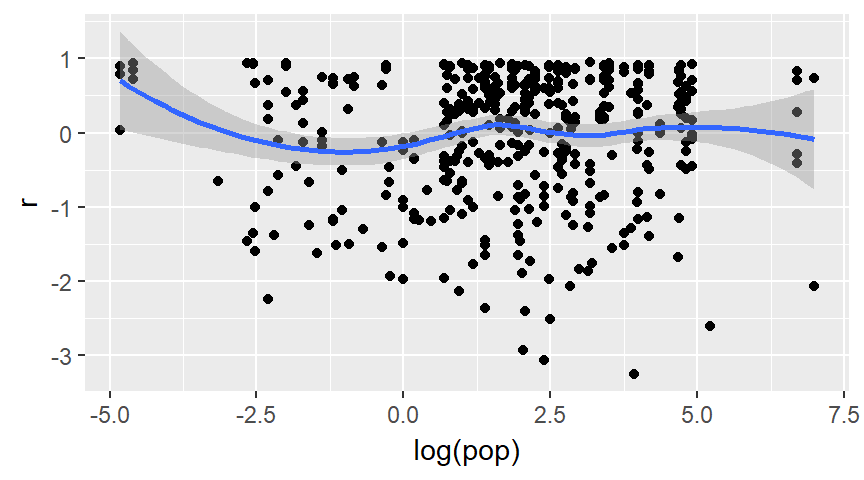

```r
ggplot(leader, aes(log(pop), r)) +
  geom_point()                   +
  geom_smooth(se=TRUE)
```

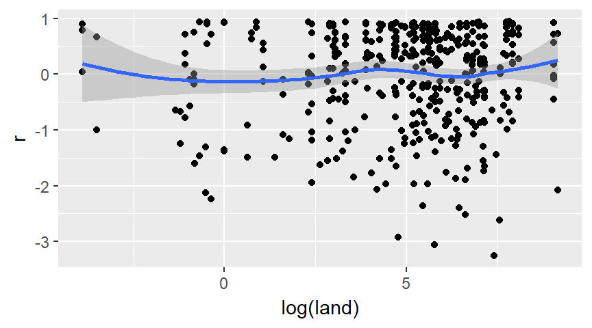

```r
ggplot(leader, aes(log(land), r))     +
  geom_point()                   +
  geom_smooth(se=TRUE)
```

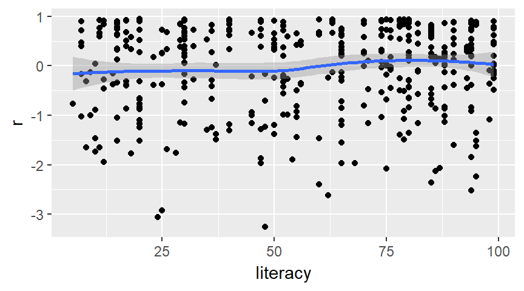

```r
ggplot(leader, aes(literacy, r)) +
  geom_point()                   +
  geom_smooth(se=TRUE)
```

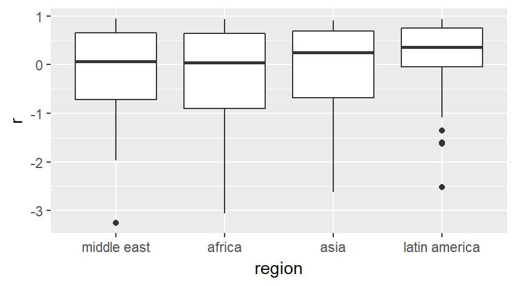

```r
ggplot(leader, aes(region, r))   +
  geom_boxplot()
```

Update your multivariate model

```r
binary_mv2 <-
  coxph(
    binary_surv~
      manner +
      military +
      age +
      loginc +
      region,
    data=leader
  )
summary(binary_mv2)
```

```
## Call:
## coxph(formula = binary_surv ~ manner + military + age + loginc +
##     region, data = leader)
##
##   n= 438, number of events= 327
##
##                                    coef exp(coef) se(coef)      z Pr(>|z|)
## mannernonconstitutional ascent  0.34961   1.41851  0.15279  2.288  0.02213
## militaryyes                    -0.20673   0.81324  0.15670 -1.319  0.18706
## age                             0.02230   1.02255  0.00514  4.339 1.43e-05
## loginc                         -0.18795   0.82866  0.07040 -2.670  0.00759
## regionafrica                   -0.37780   0.68537  0.21571 -1.751  0.07986
## regionasia                     -0.21214   0.80885  0.22368 -0.948  0.34292
## regionlatin america             0.51930   1.68085  0.18143  2.862  0.00421
##
## mannernonconstitutional ascent *
## militaryyes
## age                            ***
## loginc                         **
## regionafrica                   .
## regionasia
## regionlatin america            **
## ---
## Signif. codes:  0 '***' 0.001 '**' 0.01 '*' 0.05 '.' 0.1 ' ' 1
##
##                                exp(coef) exp(-coef) lower .95 upper .95
## mannernonconstitutional ascent    1.4185     0.7050    1.0514    1.9138
## militaryyes                       0.8132     1.2297    0.5982    1.1056
## age                               1.0226     0.9779    1.0123    1.0329
## loginc                            0.8287     1.2068    0.7219    0.9513
## regionafrica                      0.6854     1.4591    0.4491    1.0460
## regionasia                        0.8089     1.2363    0.5218    1.2539
## regionlatin america               1.6809     0.5949    1.1779    2.3986
##
## Concordance= 0.623  (se = 0.021 )
## Rsquare= 0.127   (max possible= 1 )
## Likelihood ratio test= 59.36  on 7 df,   p=2.024e-10
## Wald test            = 58.76  on 7 df,   p=2.669e-10
## Score (logrank) test = 60.09  on 7 df,   p=1.451e-10
```

Compute the Schoenfeld residuals to look for non-proportional hazards.

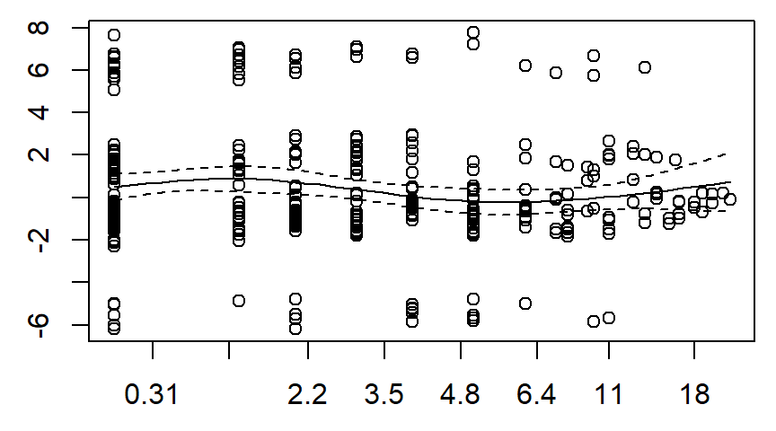

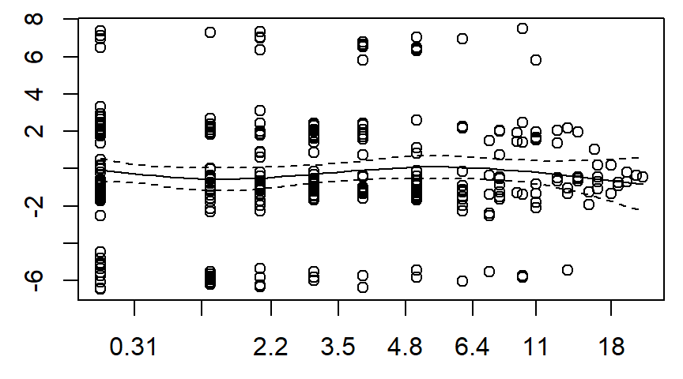

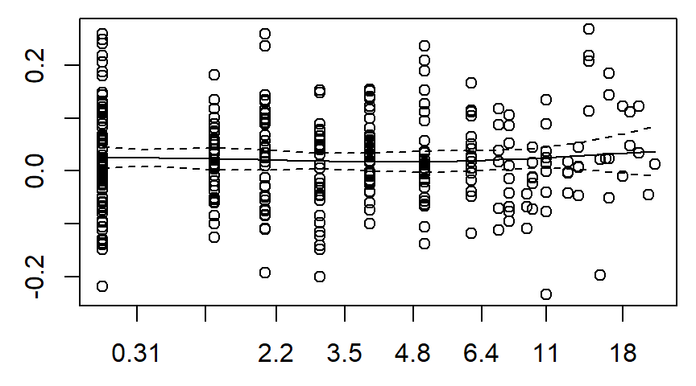

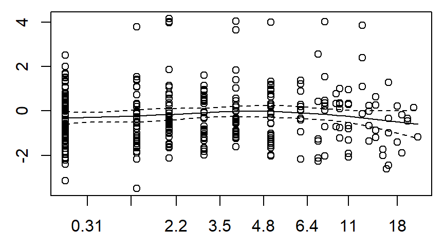

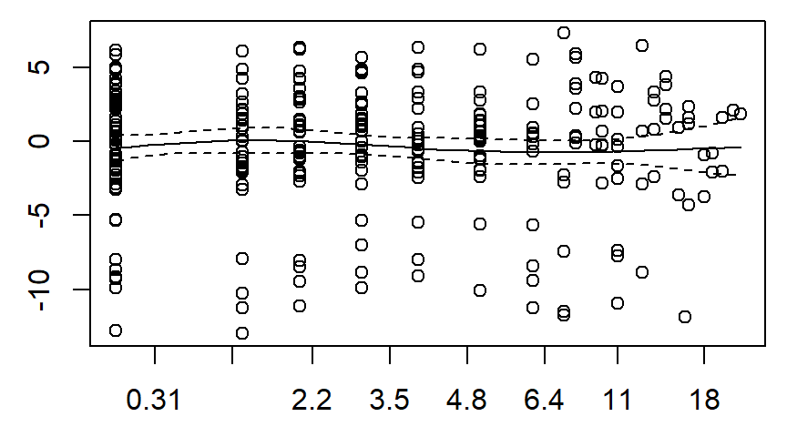

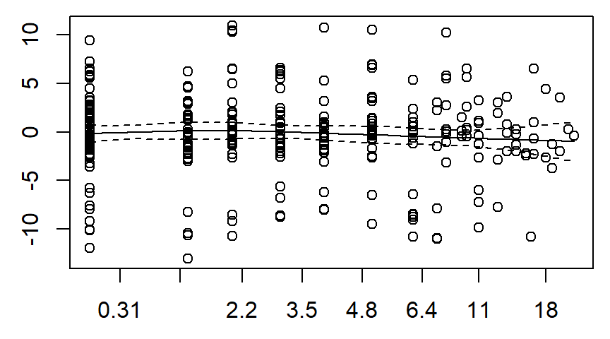

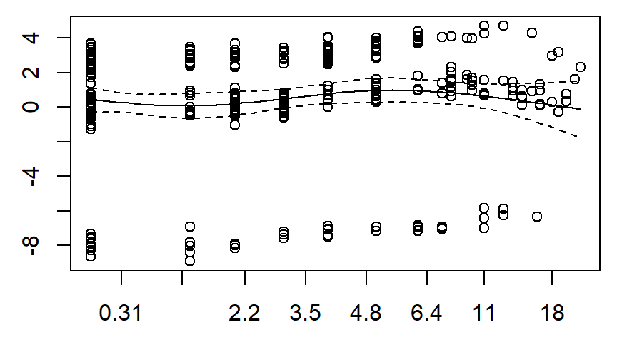

```r
par(mar=c(2.6, 2.6, 0.6, 0.6))
leader_residuals <- cox.zph(binary_mv2)
plot(leader_residuals)
```

## Competing risk models

If there are two or more causes of death and you are interested in developing a model for the individual causes, then you need a competing risk model.

The competing risk model assumes that the overal hazard function, h(t), can be written as

$h(t) = \sum_j h_j(t)$,

where $h_j(t)$ is the hazard function for the jth cause of death.

This implies that the overall cumulative hazard, H(t), is equal to

$H(t) = \sum_j H_j(t)$

where $H_j(t)$ is the cumulative hazard for the jth cause of death.

With a bit of math, you can easily show that the overall cumulative density function, F(t)=1-S(t), can be decomposed into

$F(t) = \sum_j F_j(t)$

where

$F_j(t) = \int_0^t f_j(u) S(u)dt$

Notice that $F_j$ is not a cumulative distribution function. In fact, as t approaches infinity, $F_j(t)$ approaches $P_j$, the probability for the jth cause of death. $F_j$ is called the subdistribution or the cumulative incidence function.

You can estimate $F_j$ with the formula

$\hat{F}_j(t) = \sum_{t_{(i)}<t} \hat{h}_j(t_{(i)}) \hat{S}(t_{(i-1)})$

where $\hat{S}$ is the overall Kaplan-Meier estimate of survival,

$\hat{h}_j(t_{(i)}) = \frac{d_{ij}}{n_i}$,

and $d_{ij}$ and $n_j$ are the number of deaths at time $t_{(i)}$ due to cause j and the number of patients at risk at time $t_{(i)}$.

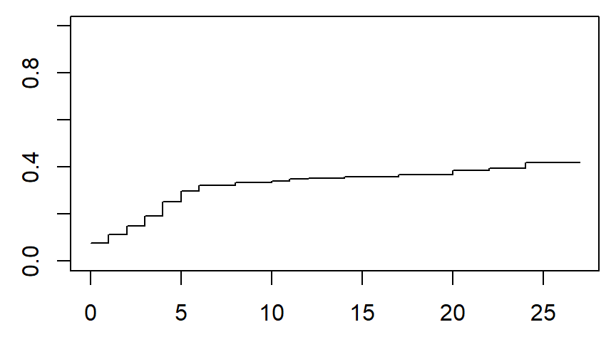

```r
par(mar=c(2.6, 2.6, 0.6, 0.6))
surv_object <-
  Surv(
    leader$years,
    leader$lost,
    type="mstate")

km_overall <- survfit(surv_object~1)
plot(
  km_overall$time,
  km_overall$pstate[ , 1],
  ylim=0:1, type="s")
```

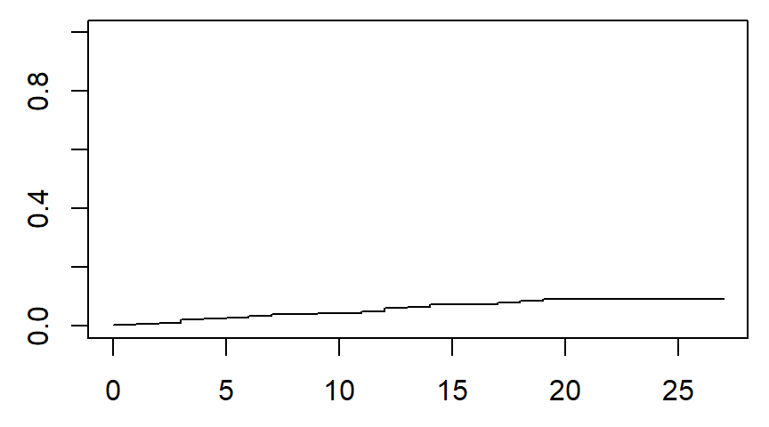

```r
plot(
  km_overall$time,
  km_overall$pstate[ , 2],
  ylim=0:1, type="s")
```

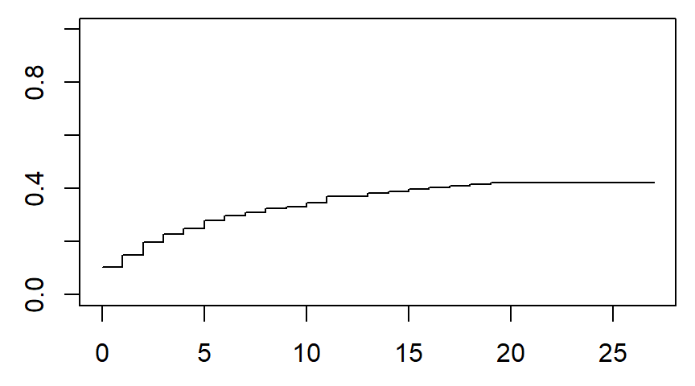

```r
plot(
  km_overall$time,
  km_overall$pstate[ , 3],
  ylim=0:1, type="s")
```

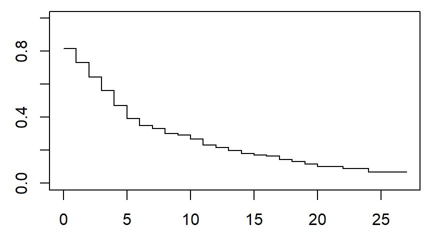

```r
plot(
  km_overall$time,
  km_overall$pstate[ , 4],
  ylim=0:1, type="s")
```

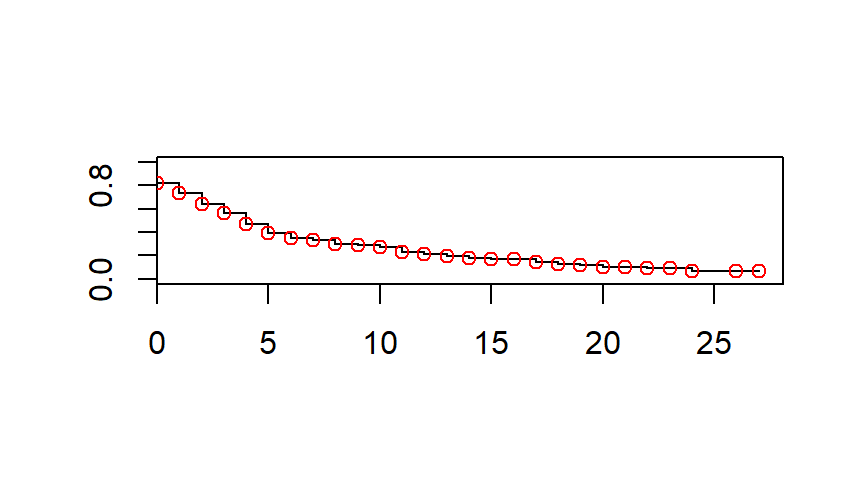

```r
km_single <-
  survfit(
    Surv(
      leader$years,
      leader$lost!="still in power")~1)
plot(km_single, ylim=0:1, conf.int=FALSE)
points(
  km_overall$time,
  km_overall$pstate[ , 4],
  col="red")
```

```r
head(tidy(km_overall))
```

```
##   time n.risk n.event n.censor   estimate  std.error conf.high   conf.low
## 1    0      0      34        7 0.07762557 0.01278554 0.1023474 0.05222287
## 2    1      0      15       10 0.11255708 0.01515195 0.1417629 0.08235733
## 3    2      0      15        9 0.14863765 0.01716106 0.1816170 0.11432934
## 4    3      0      17        8 0.19095540 0.01912731 0.2275889 0.15258442
## 5    4      0      24        5 0.25290061 0.02141794 0.2937214 0.20972045
## 6    5      0      17        8 0.29801795 0.02271825 0.3411621 0.25204849
##                 state
## 1 constitutional exit
## 2 constitutional exit
## 3 constitutional exit
## 4 constitutional exit
## 5 constitutional exit
## 6 constitutional exit
```

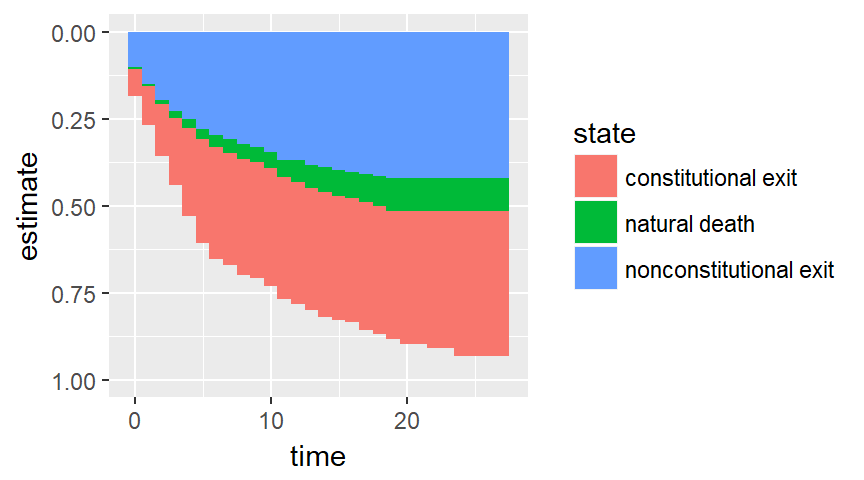

```r
km_overall %>% tidy -> km_overall_tidy
km_overall_tidy %>%
  filter(time==24) %>%
  mutate(time=25) %>%
  bind_rows(km_overall_tidy) -> km_overall_tidy
ggplot(
  data=km_overall_tidy,
  aes(time, estimate, fill=state)) +
  scale_y_reverse()                +
  expand_limits(y=1)               +
  geom_col(width=1)
```

Let’s look at a couple of subsets.

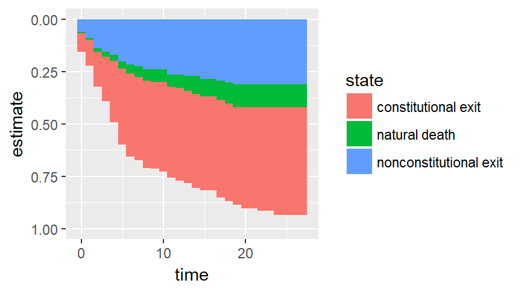

```r
sb1 <- leader$manner=="constitutional ascent"
km_sb1 <- survfit(surv_object~1, subset=sb1)
km_sb1 %>% tidy -> km_sb1_tidy
km_sb1_tidy %>%
  filter(time==20) %>%
  mutate(time=21) %>%
  bind_rows(km_sb1_tidy) -> km_sb1_tidy
km_sb1_tidy %>%
  filter(time==24) %>%
  mutate(time=25) %>%
  bind_rows(km_sb1_tidy) -> km_sb1_tidy
ggplot(
  data=km_sb1_tidy,
  aes(time, estimate, fill=state)) +
  scale_y_reverse()                +
  expand_limits(y=1)               +
  expand_limits(x=27)              +
  geom_col(width=1)
```

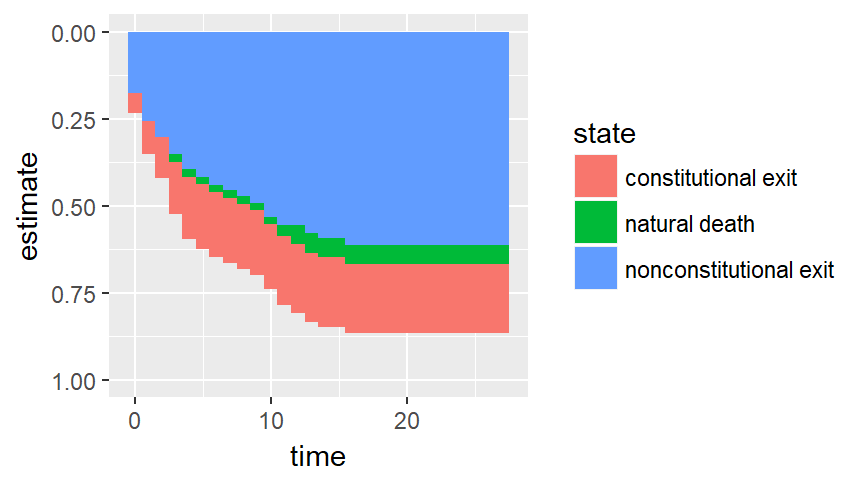

```r
sb2 <- leader$manner=="nonconstitutional ascent"
km_sb2 <- survfit(surv_object~1, subset=sb2)
km_sb2 %>% tidy -> km_sb2_tidy
for (i in 22:27) {
  km_sb2_tidy %>%
    filter(time==21) %>%
    mutate(time=i) %>%
    bind_rows(km_sb2_tidy) -> km_sb2_tidy
}
ggplot(
  data=km_sb2_tidy,
  aes(time, estimate, fill=state)) +
  scale_y_reverse()                +
  expand_limits(y=1)               +
  expand_limits(x=27)              +
  geom_col(width=1)
```

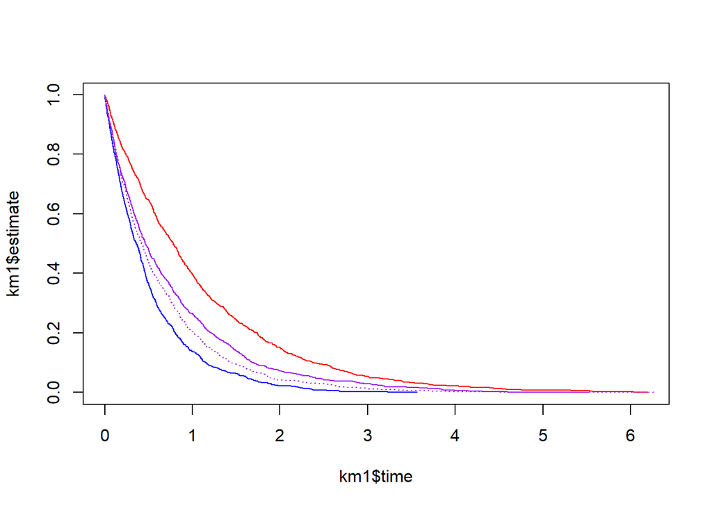

```r
n <- 1000
y1 <- rexp(n, 1)
y2 <- rexp(n, 2)
y3 <- rexp(n, rep(1:2, n/2))
y4 <- rexp(n, 1.5)
cens <- rep(1, n)
km1 <- tidy(survfit(Surv(y1, cens)~1))
km2 <- tidy(survfit(Surv(y2, cens)~1))
km3 <- tidy(survfit(Surv(y3, cens)~1))
km4 <- tidy(survfit(Surv(y4, cens)~1))
plot(km1$time, km1$estimate, type="l", col="red")
lines(km2$time, km2$estimate, col="blue")
lines(km3$time, km3$estimate, col="purple")
lines(km4$time, km4$estimate, col="purple", lty="dotted")
```

Save everything for possible later re-use.

```r
save.image("../../data/survival-lecture-8.RData")
```